# 12. Excel Export

Chris Bailiss

2019-11-01

## In This Vignette

- Overview
- Basic Export (no styling)
- Styling and Formatting
- Formatting Cell Values
- Formatting Headings
- Export of NA, NaN, -Inf and Inf
- Column Widths and Row Heights
- Performance
- Styling Reference
- Further Reading

## Overview

The pivottabler package can export a pivot table to an Excel file. Only Excel 2007 onwards (*.xlsx) files are supported. This export uses the openxlsx package.

This vignette starts with a basic (unformatted) export. Following this are various styled/formatted examples.

## Basic Export (no styling)

Exporting a pivot table to an Excel table is reasonably straightforward:

1. Create a pivot table in R using `pivottabler`,
2. Using the openxlsx package, create a new Excel file and add a worksheet (or open an existing worksheet),
3. Call the `writeToExcelWorksheet` method on the pivot table.
4. Using the openxlsx package, save the workbook.

```r
library(pivottabler)
pt <- PivotTable$new()
pt$addData(bhmtrains)
pt$addColumnDataGroups("TrainCategory")
pt$addColumnDataGroups("PowerType")
pt$addRowDataGroups("TOC")
pt$defineCalculation(calculationName="TotalTrains", summariseExpression="n()")
pt$evaluatePivot()

library(openxlsx)
wb <- createWorkbook(creator = Sys.getenv("USERNAME"))
addWorksheet(wb, "Data")
pt$writeToExcelWorksheet(wb=wb, wsName="Data",
                         topRowNumber=1, leftMostColumnNumber=1, applyStyles=FALSE)
saveWorkbook(wb, file="C:\\test.xlsx", overwrite = TRUE)
```

[figure not shown]

Basic Excel Export (unstyled)

## Styling and Formatting

The Excel output from the `pivottabler` package has been written so that, as much as possible, the same styling used for HTML output also works for the Excel output, i.e. most of the styling described in the Styling vignette can also be used when writing a pivot table to an Excel file.

More specifically, the styling described in the Styling vignette uses CSS (Cascading Style Sheet) definitions for styles. The `pivottabler` package interprets these CSS definitions and maps them to the styling used in Excel/by the openxlsx package.

This means, once a pivot table has been styled as described in the Styling vignette, the pivot table in the Excel workbook can be styled simply by specifying `applyStyles=TRUE`.

[figure not shown]

Using CSS Styling

```r
library(pivottabler)
pt <- PivotTable$new()
pt$addData(bhmtrains)
pt$addColumnDataGroups("TrainCategory")
pt$addColumnDataGroups("PowerType")
pt$addRowDataGroups("TOC")
pt$defineCalculation(calculationName="TotalTrains", summariseExpression="n()")
pt$evaluatePivot()

library(openxlsx)
wb <- createWorkbook(creator = Sys.getenv("USERNAME"))
addWorksheet(wb, "Data")
pt$writeToExcelWorksheet(wb=wb, wsName="Data",
                         topRowNumber=1, leftMostColumnNumber=1,
                         applyStyles=TRUE, mapStylesFromCSS=TRUE)
saveWorkbook(wb, file="C:\\test.xlsx", overwrite = TRUE)
```

In general, the CSS mappings described above will simplify outputting to Excel. However, not all CSS definitions can be mapped to Excel. Excel also has some style settings that don’t map to CSS. There may also be occasions where different styling is desired in Excel vs. HTML. To support all of these scenarios, a second set of styling properties are also supported. These all begin with “xl-” and have roughly similar (but not exactly the same) names to their CSS counterparts, e.g. the property corresponding to CSS “font-family” is “xl-font-name”. If both the “xl-…” Excel property and the CSS property are specified, the Excel value is used. If `mapStylesFromCSS=FALSE` is specified, then the CSS properties are ignored and only the “xl-…” properties are used.

The table at the bottom of this vignette details the full set of CSS and Excel style properties that are supported.

## Formatting Cell Values

There are a few different ways for format the values written into the worksheet. These are controlled by the `outputValuesAs` parameter, which has allowed values: “rawValue”, “formattedValueAsText” and “formattedValueAsNumber”.

The following pivot table will be used to illustrate the different values for this parameter:

```r
library(pivottabler)
library(dplyr)
library(lubridate)

# derive some additional data
trains <- mutate(bhmtrains,
   ArrivalDelta=difftime(ActualArrival, GbttArrival, units="mins"),
   ArrivalDelay=ifelse(ArrivalDelta<0, 0, ArrivalDelta))

# create the pivot table
pt <- PivotTable$new()
pt$addData(trains)
pt$addColumnDataGroups("TrainCategory")
pt$addColumnDataGroups("PowerType")
pt$addRowDataGroups("TOC", totalCaption="All TOCs")
pt$defineCalculation(calculationName="MeanArrivalDelay", caption="Mean Arr. Delay",
                     summariseExpression="mean(ArrivalDelay, na.rm=TRUE)", format="%.1f")
pt$renderPivot()
```

[interactive chart not shown]

### Raw Value

Specifying `outputValuesAs="rawValue"` will output the raw unformatted values. This is also the default if no value is explicitly specified for the `outputValuesAs` parameter.

```r
library(pivottabler)
library(dplyr)
library(lubridate)

# derive some additional data
trains <- mutate(bhmtrains,
   ArrivalDelta=difftime(ActualArrival, GbttArrival, units="mins"),
   ArrivalDelay=ifelse(ArrivalDelta<0, 0, ArrivalDelta))

# create the pivot table
pt <- PivotTable$new()
pt$addData(trains)
pt$addColumnDataGroups("TrainCategory")
pt$addColumnDataGroups("PowerType")
pt$addRowDataGroups("TOC", totalCaption="All TOCs")
pt$defineCalculation(calculationName="MeanArrivalDelay", caption="Mean Arr. Delay",
                     summariseExpression="mean(ArrivalDelay, na.rm=TRUE)", format="%.1f")
pt$evaluatePivot()

library(openxlsx)
wb <- createWorkbook(creator = Sys.getenv("USERNAME"))
addWorksheet(wb, "Data")
pt$writeToExcelWorksheet(wb=wb, wsName="Data",
                         topRowNumber=1, leftMostColumnNumber=1,
                         outputValuesAs="rawValue",
                         applyStyles=TRUE, mapStylesFromCSS=TRUE)
saveWorkbook(wb, file="C:\\test.xlsx", overwrite = TRUE)
```

Rounding the values as part of the calculation definition is one option that could be used with `outputValuesAs="rawValue"`.

[figure not shown]

Exporting raw unformatted values

### Formatted Values (as text)

Specifying `outputValuesAs="formattedValueAsText"` will output the formatted values - i.e. the calculation results that have been formatted according to the `format` parameter in the `defineCalculation()` function. The formatted values are text however, so when exported to Excel this typically results in a warning in the corner of each cell that the number in the cell has been stored as text:

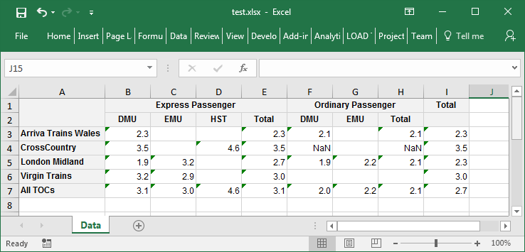

Exporting formatted values as text

### Formatted Values (as numbers)

Specifying `outputValuesAs="formattedValueAsNumber"` will output the formatted values as numbers - i.e. the same values as shown in the screen shot above, but converted back to numerical values (where possible) - so eliminating the warnings shown above:

[figure not shown]

Exporting formatted values as numbers

### Using Excel to format the values (recommended)

The `outputValuesAs` parameter provides a simple way to control value formatting. However, this applies to every cell in the pivot table, so is not a very fine-grained control.

A better option is to output the raw unformatted values to Excel and then specify an Excel format string as part of the calculation definition to allow Excel to format the values.

[figure not shown]

Exporting raw values with an Excel format string

```r
library(pivottabler)
library(dplyr)
library(lubridate)

# derive some additional data
trains <- mutate(bhmtrains,
   ArrivalDelta=difftime(ActualArrival, GbttArrival, units="mins"),
   ArrivalDelay=ifelse(ArrivalDelta<0, 0, ArrivalDelta))

# create the pivot table
pt <- PivotTable$new()
pt$addData(trains)
pt$addColumnDataGroups("TrainCategory")
pt$addColumnDataGroups("PowerType")
pt$addRowDataGroups("TOC", totalCaption="All TOCs")
pt$defineCalculation(calculationName="MeanArrivalDelay", caption="Mean Arr. Delay",
                     summariseExpression="mean(ArrivalDelay, na.rm=TRUE)", format="%.1f",
                     cellStyleDeclarations=list("xl-value-format"="##0.0"))
pt$evaluatePivot()

library(openxlsx)
wb <- createWorkbook(creator = Sys.getenv("USERNAME"))
addWorksheet(wb, "Data")
pt$writeToExcelWorksheet(wb=wb, wsName="Data",
                         topRowNumber=1, leftMostColumnNumber=1,
                         outputValuesAs="rawValue",
                         applyStyles=TRUE, mapStylesFromCSS=TRUE)
saveWorkbook(wb, file="C:\\test.xlsx", overwrite = TRUE)
```

## Formatting Headings

The formatting of headings is controlled by the `outputHeadingsAs` parameter, which has allowed values: “rawValue”, “formattedValueAsText” and “formattedValueAsNumber”. The values have the same behaviour as described above for the `outputValuesAs` parameter. The default value of `outputHeadingsAs` is “formattedValueAsText”.

## Export of NA, NaN, -Inf and Inf

The `pt$writeToExcelWorksheet(...)` function supports an `exportOptions` parameter that provides control over how NA, NaN, -Inf and Inf values in R are exported to Excel. See the Appendix: Details vignette for details.

## Column Widths and Row Heights

It is possible to specifying a minimum row height and/or column width as part of the styling. The relevant styling properties are “xl-min-row-height” and “xl-min-column-width”.

Rows/columns are sized to meet all of the minimum sizes specified. E.g. if three cells in the same row have minimum row heights of 40, 45 and 50 specified, the row height will be set to 50.

## Performance

Creating Excel files is relatively effort intensive. Outputting pivot tables to Excel files requires more time than creating a HTML representation of a pivot table. In order of increasing time required:

- Unstyled Pivot Tables - these will be written to Excel quicker than styled pivot tables.
- Pivot tables using only base styles - i.e. where no additional styles have been applied to individual cells in the pivot table - these take a moderate amount of time to write to Excel.
- Pivot tables with styles applied to individual cells - these take the longest amount of time to write to Excel due to the extra effort of handling the styles applied to individual cells.

## Styling Reference

A reference table of the supported styling declarations can be found in the Appendix: Details vignette.

## Further Reading

The full set of vignettes is:

1. Introduction
2. Data Groups
3. Calculations
4. Outputs
5. Latex Output
6. Styling
7. Finding and Formatting
8. Cell Context
9. Irregular Layout
10. Performance
11. Shiny
12. Excel Export
13. Appendix: Details
14. Appendix: Calculations
15. Appendix: Class Overview